# INN Hotels Project

#### checking performance on training set

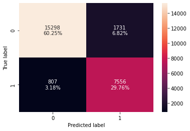

```python
confusion_matrix_sklearn(best_model, X_train, y_train)
```

```python
decision_tree_post_perf_train = model_performance_classification_sklearn(best_model, x_train, y_train)

print (decision_tree_post_perf_train)
```

```
   Accuracy    Recall  Precision        F1
0  0.900047  0.903504    0.81361  0.856204
```

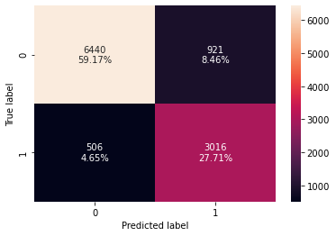

```python
confusion_matrix_sklearn(best_model, X_test, y_test)
```

```python
decision_tree_post_test = model_performance_classification_sklearn(best_model, X_test, y_test)

print (decision_tree_post_test)
```

```
   Accuracy    Recall  Precision        F1
0  0.868878  0.856332   0.766066  0.808687
```

- Decision tree has generalized on both training and test now
- Higher recall but a greater different between the Recall and Precision

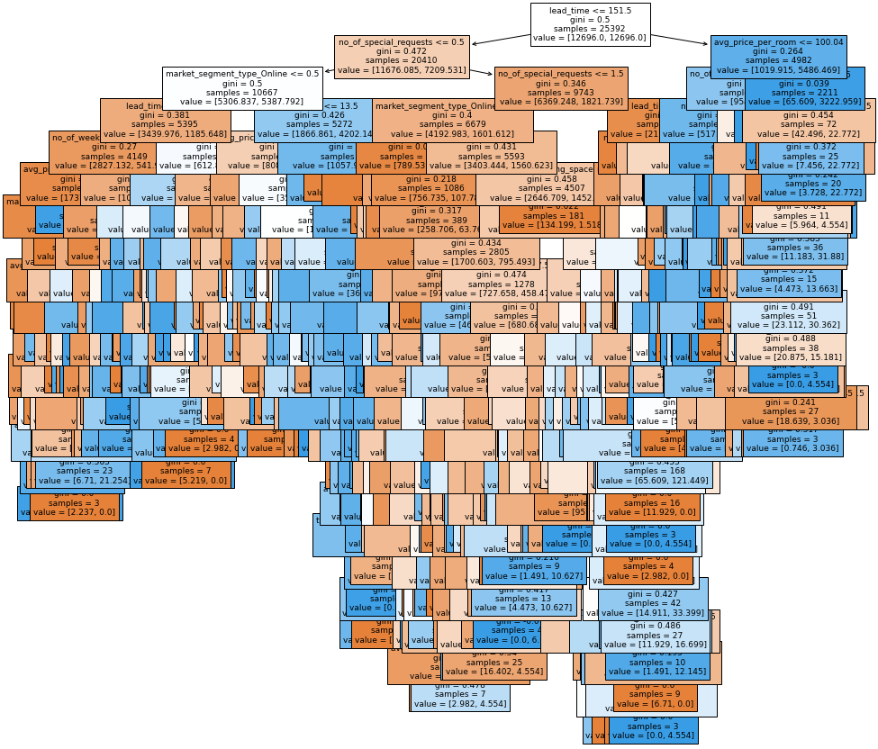

```python
plt.figure(figsize=(15, 15))

out = tree.plot_tree(
    best_model,
    feature_names=feature_names,
    filled=True,
    fontsize=9,
    node_ids=False,
    class_names=None,
)
for o in out:
    arrow = o.arrow_patch
    if arrow is not None:
        arrow.set_edgecolor("black")
        arrow.set_linewidth(1)
plt.show()
```

```python
# Text report showing the rules of a decision tree -

print(tree.export_text(best_model, feature_names=feature_names, show_weights=True))
```

```
|--- lead_time <= 151.50
|   |--- no_of_special_requests <= 0.50
|   |   |--- market_segment_type_Online <= 0.50
|   |   |   |--- lead_time <= 90.50
|   |   |   |   |--- no_of_weekend_nights <= 0.50
|   |   |   |   |   |--- avg_price_per_room <= 196.50
|   |   |   |   |   |   |--- market_segment_type_Offline <= 0.50
|   |   |   |   |   |   |   |--- lead_time <= 16.50
|   |   |   |   |   |   |   |   |--- avg_price_per_room <= 68.50
|   |   |   |   |   |   |   |   |   |--- weights: [207.26, 10.63] class: 0
|   |   |   |   |   |   |   |   |--- avg_price_per_room >  68.50
|   |   |   |   |   |   |   |   |   |--- arrival_date <= 29.50
|   |   |   |   |   |   |   |   |   |   |--- no_of_adults <= 1.50
|   |   |   |   |   |   |   |   |   |   |   |--- truncated branch of depth 2
|   |   |   |   |   |   |   |   |   |   |--- no_of_adults >  1.50
|   |   |   |   |   |   |   |   |   |   |   |--- truncated branch of depth 5
|   |   |   |   |   |   |   |   |   |--- arrival_date >  29.50
|   |   |   |   |   |   |   |   |   |   |--- weights: [2.24, 7.59] class: 1
|   |   |   |   |   |   |   |--- lead_time >  16.50
|   |   |   |   |   |   |   |   |--- avg_price_per_room <= 135.00
|   |   |   |   |   |   |   |   |   |--- arrival_month <= 11.50
|   |   |   |   |   |   |   |   |   |   |--- repeated_guest <= 0.50
|   |   |   |   |   |   |   |   |   |   |   |--- truncated branch of depth 4
|   |   |   |   |   |   |   |   |   |   |--- repeated_guest >  0.50
|   |   |   |   |   |   |   |   |   |   |   |--- weights: [11.18, 0.00] class: 0
|   |   |   |   |   |   |   |   |   |--- arrival_month >  11.50
|   |   |   |   |   |   |   |   |   |   |--- weights: [21.62, 0.00] class: 0
|   |   |   |   |   |   |   |   |--- avg_price_per_room >  135.00
|   |   |   |   |   |   |   |   |   |--- weights: [0.00, 12.14] class: 1
|   |   |   |   |   |   |--- market_segment_type_Offline >  0.50
|   |   |   |   |   |   |   |--- weights: [1199.59, 0.00] class: 0
|   |   |   |   |   |--- avg_price_per_room >  196.50
|   |   |   |   |   |   |--- weights: [0.75, 25.81] class: 1
|   |   |   |   |--- no_of_weekend_nights >  0.50
|   |   |   |   |   |--- lead_time <= 68.50
|   |   |   |   |   |   |--- arrival_month <= 9.50
|   |   |   |   |   |   |   |--- avg_price_per_room <= 63.29
|   |   |   |   |   |   |   |   |--- arrival_date <= 20.50
|   |   |   |   |   |   |   |   |   |--- type_of_meal_plan_Not Selected <= 0.50
|   |   |   |   |   |   |   |   |   |   |--- weights: [41.75, 0.00] class: 0
```

[output cut: 651 more lines]

```
|   |   |   |   |   |   |--- weights: [5.96, 4.55] class: 0
|   |--- avg_price_per_room >  100.04
|   |   |--- arrival_month <= 11.50
|   |   |   |--- no_of_special_requests <= 2.50
|   |   |   |   |--- weights: [0.00, 3200.19] class: 1
|   |   |   |--- no_of_special_requests >  2.50
|   |   |   |   |--- weights: [23.11, 0.00] class: 0
|   |   |--- arrival_month >  11.50
|   |   |   |--- no_of_special_requests <= 0.50
|   |   |   |   |--- weights: [35.04, 0.00] class: 0
|   |   |   |--- no_of_special_requests >  0.50
|   |   |   |   |--- arrival_date <= 24.50
|   |   |   |   |   |--- weights: [3.73, 0.00] class: 0
|   |   |   |   |--- arrival_date >  24.50
|   |   |   |   |   |--- weights: [3.73, 22.77] class: 1
```

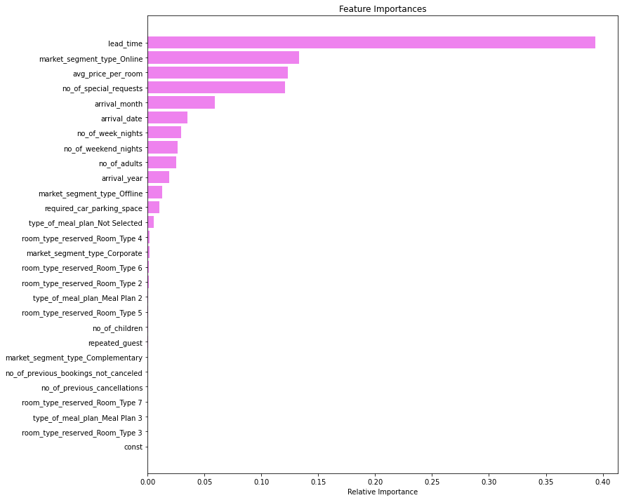

```python
importances = best_model.feature_importances_
indices = np.argsort(importances)

plt.figure(figsize=(12, 12))
plt.title("Feature Importances")
plt.barh(range(len(indices)), importances[indices], color="violet", align="center")
plt.yticks(range(len(indices)), [feature_names[i] for i in indices])
plt.xlabel("Relative Importance")
plt.show()
```

- Feature importance are the same
- Tree is complex compared to before

### Comparing all the decision tree models

```python
# training performance comparison

models_train_comp_df = pd.concat(
    [
        decision_tree_perf_train.T,
        decision_tree_tune_train.T,
        decision_tree_post_perf_train.T,
    ],
    axis=1,
)

models_train_comp_df.columns = ['Sklearn DT', 'PrePrune DT', 'PostPrune DT']
print("Training performance comparison:")
models_train_comp_df
```

```
Training performance comparison:
```

|  | Sklearn DT | PrePrune DT | PostPrune DT |
| --- | --- | --- | --- |
| Accuracy | 0.994211 | 0.831010 | 0.900047 |
| Recall | 0.986608 | 0.786201 | 0.903504 |
| Precision | 0.995776 | 0.724278 | 0.813610 |
| F1 | 0.991171 | 0.753971 | 0.856204 |

```python
# training performance comparison

models_test_comp_df = pd.concat(
    [
        decision_tree_perf_test.T,
        decision_tree_tune_test.T,
        decision_tree_post_test.T,
    ],
    axis=1,
)

models_test_comp_df.columns = ['Sklearn DT', 'PrePrune DT', 'PostPrune DT']
print("Testing performance comparison:")
models_test_comp_df
```

```
Testing performance comparison:
```

|  | Sklearn DT | PrePrune DT | PostPrune DT |
| --- | --- | --- | --- |
| Accuracy | 0.874299 | 0.834972 | 0.868878 |
| Recall | 0.814026 | 0.783362 | 0.856332 |
| Precision | 0.800838 | 0.727584 | 0.766066 |
| F1 | 0.807378 | 0.754444 | 0.808687 |

**Observations**

- Decision tree model with pre-pruning has given a generalized performance with balance recall and precision.
- Decision tree model with post-pruning have a high F1 socre compared to the rest however there is a bigger difference between the recall and precision.
- The hotel should use a the pre-puned Decision tree model to have a balanced approached of brand reputation and resources.

### Conclusions

- We analyzed the INN Hotel's data using different techniques and used Decision Tree Classifier to build a predictive model for the same.
- The model built can be used to predict if a customer is going to cancel on a booking or not.
- We visualized different trees and their confusion matrix to get a better understanding of the model.
- We verified the fact that how much less data preparation is needed for Decision Trees and such a simple model gave good results even with outliers and imbalanced classes which shows the robustness of Decision Trees.
- Lead Time, Number of Special Request, Average Price per Room and Market Segments Online are the most important features in the models.
- Lead Time and Average Price per Room have a positive relationship wiht bookings getting canceled while Special Requests has a negative relationhsip with bookings getting canceled.

### Business Recommendations

```
a) As seen from the analysis it would be beneficial for the hotel to market special requests as more special requests allow for the booking to not be canceled.

b) With rooms that have average prices higher, hotels should inform the customer while the customer is reserving that there will be a penalty of some sort such as not getting a full refund of the cost.
 - This will allow the hotel to not lose all of their money.

c) Guests that book more than 151 days should receive notifications about their bookings.

- This will allow enough time to reserve the same room to be re-booked if the customer is wanted to cancel.
```